# Final Project

Chris Lefrak

2022-06-08

# Introduction

```r
# read in data
red_wine <- read.csv("data/winequality_red.csv")
white_wine <- read.csv("data/winequality_white.csv")

# add columns for color so we can
# differentiate once concatenated
white_wine$color <- as.factor("White")
red_wine$color <- as.factor("Red")

# concatenate data frames
all_wine <- rbind(red_wine, white_wine) %>%
  clean_names() %>% # replaces periods with underscores in column names
  rename(ph = p_h) # get rid of underscore in pH column name

# display
all_wine%>%
  head()
```

```
##   fixed_acidity volatile_acidity citric_acid residual_sugar chlorides
## 1           7.4             0.70        0.00            1.9     0.076
## 2           7.8             0.88        0.00            2.6     0.098
## 3           7.8             0.76        0.04            2.3     0.092
## 4          11.2             0.28        0.56            1.9     0.075
## 5           7.4             0.70        0.00            1.9     0.076
## 6           7.4             0.66        0.00            1.8     0.075
##   free_sulfur_dioxide total_sulfur_dioxide density   ph sulphates alcohol
## 1                  11                   34  0.9978 3.51      0.56     9.4
## 2                  25                   67  0.9968 3.20      0.68     9.8
## 3                  15                   54  0.9970 3.26      0.65     9.8
## 4                  17                   60  0.9980 3.16      0.58     9.8
## 5                  11                   34  0.9978 3.51      0.56     9.4
## 6                  13                   40  0.9978 3.51      0.56     9.4
##   quality color
## 1       5   Red
## 2       5   Red
## 3       5   Red
## 4       6   Red
## 5       5   Red
## 6       5   Red
```

First, let’s check if our data has any missing values.

`is.na()` returns an object that is the same size as `all_wine` but with the values of `TRUE` where values are `NA` and `FALSE` where values are not `NA`.

```r
data.frame(is.na(all_wine))%>%
  head()
```

```
##   fixed_acidity volatile_acidity citric_acid residual_sugar chlorides
## 1         FALSE            FALSE       FALSE          FALSE     FALSE
## 2         FALSE            FALSE       FALSE          FALSE     FALSE
## 3         FALSE            FALSE       FALSE          FALSE     FALSE
## 4         FALSE            FALSE       FALSE          FALSE     FALSE
## 5         FALSE            FALSE       FALSE          FALSE     FALSE
## 6         FALSE            FALSE       FALSE          FALSE     FALSE
##   free_sulfur_dioxide total_sulfur_dioxide density    ph sulphates alcohol
## 1               FALSE                FALSE   FALSE FALSE     FALSE   FALSE
## 2               FALSE                FALSE   FALSE FALSE     FALSE   FALSE
## 3               FALSE                FALSE   FALSE FALSE     FALSE   FALSE
## 4               FALSE                FALSE   FALSE FALSE     FALSE   FALSE
## 5               FALSE                FALSE   FALSE FALSE     FALSE   FALSE
## 6               FALSE                FALSE   FALSE FALSE     FALSE   FALSE
##   quality color
## 1   FALSE FALSE
## 2   FALSE FALSE
## 3   FALSE FALSE
## 4   FALSE FALSE
## 5   FALSE FALSE
## 6   FALSE FALSE
```

We can now use the `sum()` function to sum all of the boolean values outputted by `is.na()`. This will tell us how many `TRUE` values there are; i.e., this will tell us how many missing values are in our data.

```r
data.frame(is.na(all_wine))%>%
  sum()
```

```
## [1] 0
```

We are lucky; this data is already very clean and has no missing values. Now we can proceed with our analysis.

We move onto setting up our initial split of the data. We randomly select 80% of the data to be used as training data to train our models, and 20% of the data to be used as testing data to assess the performance of our models. However, we also stratify the the split by our outcome variable `quality`. This ensures that the same proportion of outcomes in `quality` are found in the overall data, training data, and testing data.

```r
set.seed(42069) # for reproducibiility

# get training and testing data
wine_split <- initial_split(all_wine,prop=0.8,
                               strata=quality)

wine_train <- training(wine_split)
wine_test <- testing(wine_split)
```

We will also fold the training data with a 5-fold cross-validation to actually train the models with

```r
# cross-validation folds
wine_fold <- vfold_cv(wine_train, v=5, strata=quality)
```

# Exploratory Data Analysis

First let’s take a look at a histogram of our outcome variable `quality`

[figure not shown]

```
##
##    3    4    5    6    7    8    9
##   30  216 2138 2836 1079  193    5
```

[figure not shown]

```r
# the explicit counts visualized in the histogram above
table(all_wine$quality)
```

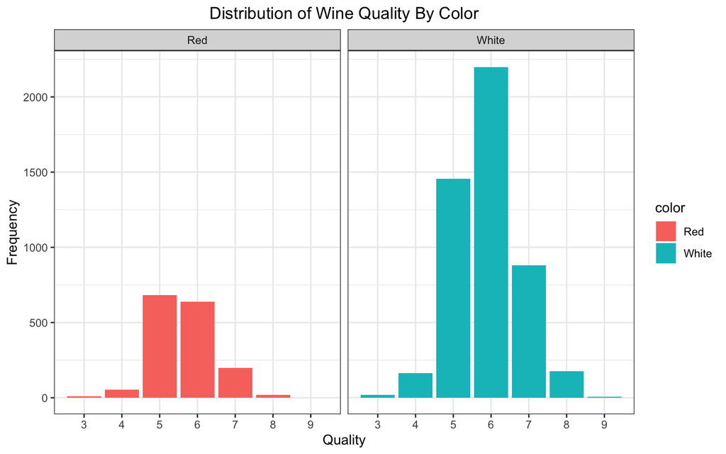

```r
all_wine %>%
  ggplot(aes(x = quality, fill=color)) +
  geom_bar()+
  facet_wrap(~color, nrow = 1)+
  ggtitle("Distribution of Wine Quality By Color") +
  labs(x="Quality", y="Frequency") +
  scale_x_continuous(breaks = seq(3,9,1),minor_breaks = NULL)+
  theme_bw()+
  theme(plot.title = element_text(hjust = 0.5))
```

# Building The Models

The ease of the `tidymodels` and `tidyverse` framework allows us to set up a single recipe that we will use to fit all of our models.

```r
wine_recipe <- recipe(quality ~ ., data = wine_train)%>%
  step_dummy("color")%>%
  step_normalize(all_predictors())
```

## Regression Models

This section we will be fitting regression model, and in the next section we will set up and use the same models but with their classification counterparts.

### Regression Model 1 - Decision Tree

```r
tree_spec <- decision_tree() %>%
  set_engine("rpart")

reg_tree_spec <- tree_spec %>%
  set_mode("regression")

reg_tree_wf <- workflow() %>%
  add_model(reg_tree_spec %>% set_args(cost_complexity = tune()))%>%
  add_recipe(wine_recipe)
```

```r
set.seed(42069)

param_grid <- grid_regular(cost_complexity(range = c(-3, -1)), levels = 10)

reg_tree_tune_res <- tune_grid(
  reg_tree_wf,
  resamples = wine_fold,
  grid = param_grid,
  #metrics = metric_set(rmse)
)
```

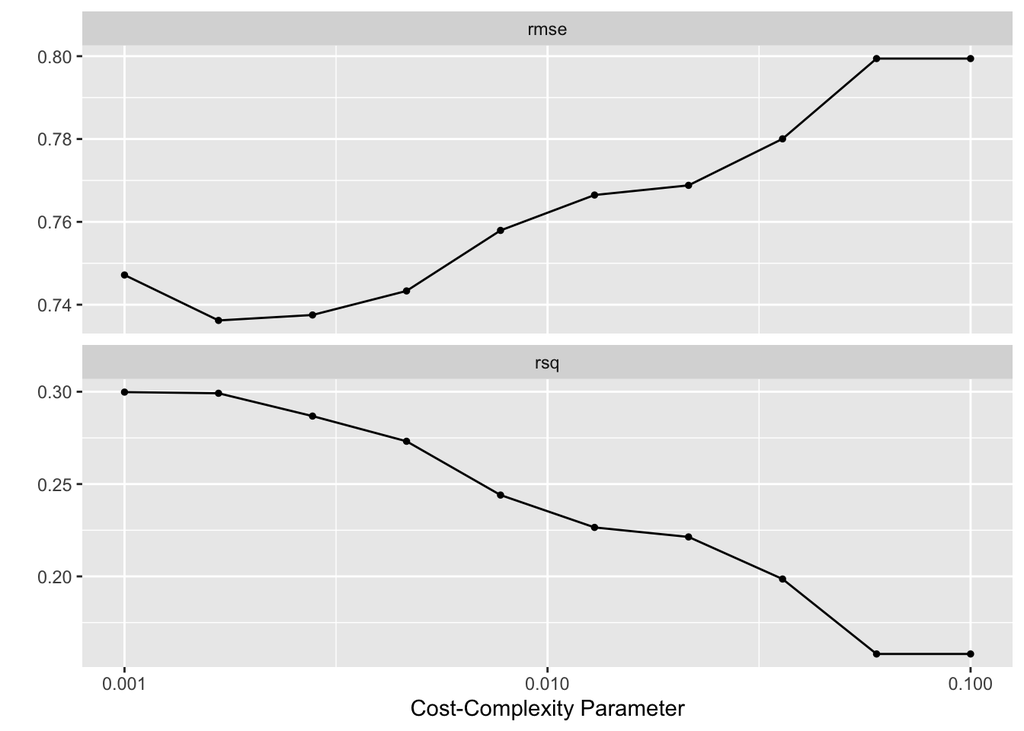

```r
autoplot(reg_tree_tune_res)
```

```r
best_complexity <- select_best(reg_tree_tune_res, metric = "rmse")

reg_tree_final <- finalize_workflow(reg_tree_wf, best_complexity)

reg_tree_final_fit <- fit(reg_tree_final, data = wine_train)
```

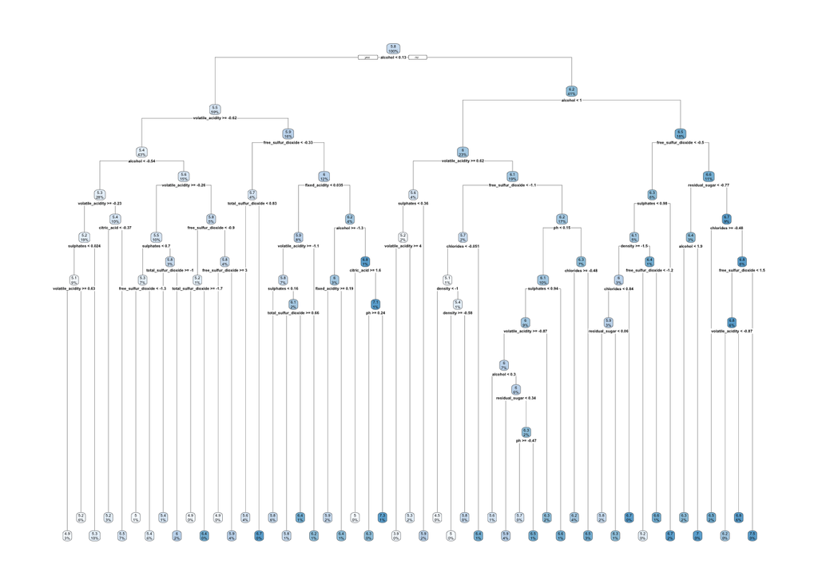

```r
reg_tree_final_fit %>%
  extract_fit_engine() %>%
  rpart.plot()
```

```r
augment(reg_tree_final_fit, new_data = wine_test) %>%
  rmse(truth = quality, estimate = .pred)
```

```
## # A tibble: 1 × 3
##   .metric .estimator .estimate
##   <chr>   <chr>          <dbl>
## 1 rmse    standard       0.740
```

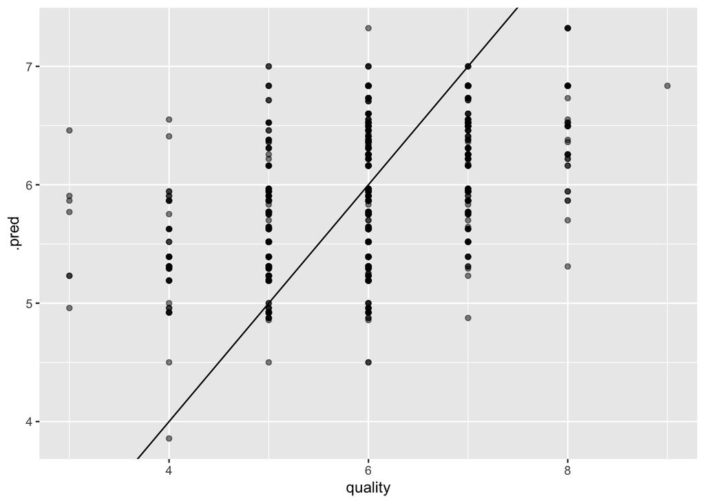

```r
augment(reg_tree_final_fit, new_data = wine_test) %>%
  ggplot(aes(quality, .pred)) +
  geom_abline() +
  geom_point(alpha = 0.5)
```

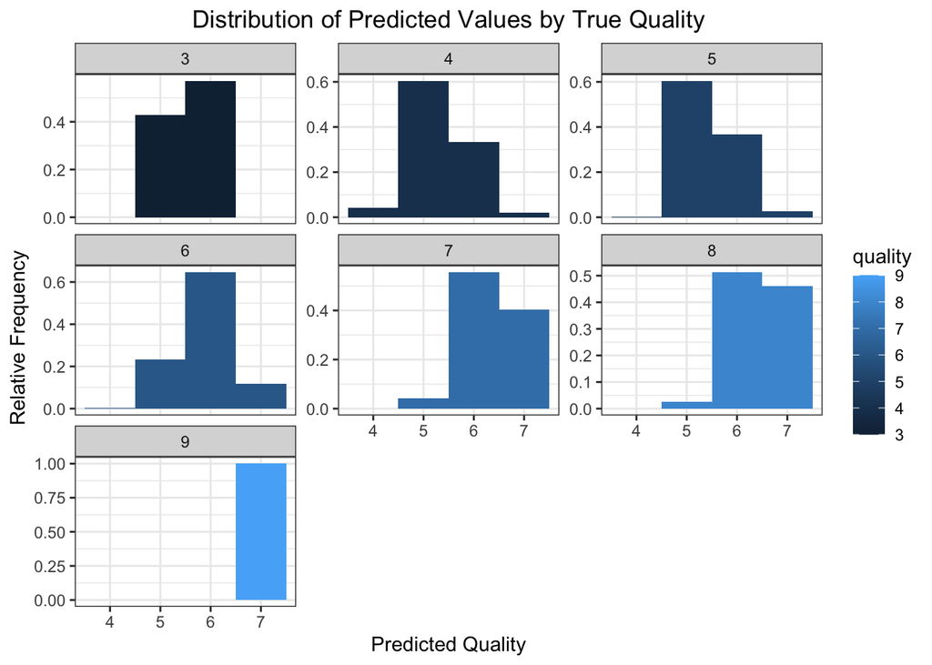

```r
augment(reg_tree_final_fit, new_data = wine_test) %>%
  ggplot(aes(x = .pred, fill=quality)) +
  geom_histogram(aes(y = stat(density)),binwidth = 1, )+
  facet_wrap(~quality, nrow = 3, scales = "free_y")+
  ggtitle("Distribution of Predicted Values by True Quality") +
  labs(x="Predicted Quality", y=" Relative Frequency") +
  scale_x_continuous(breaks = seq(3,9,1),minor_breaks = NULL)+
  theme_bw()+
  theme(plot.title = element_text(hjust = 0.5))
```

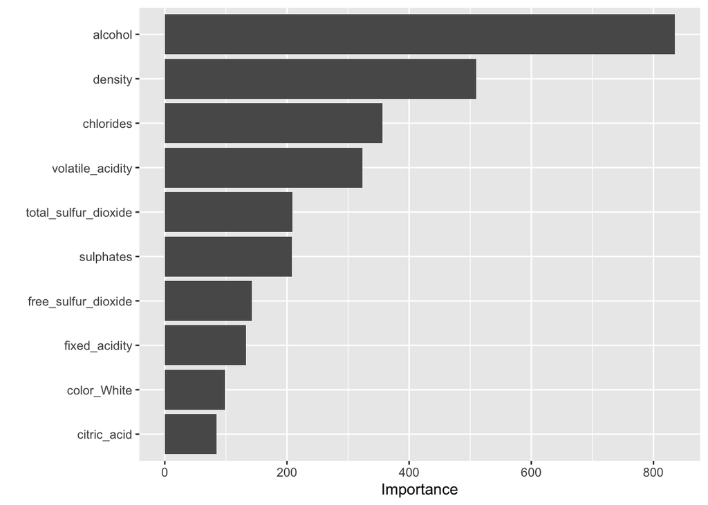

```r
reg_tree_final_fit%>%
  extract_fit_parsnip()%>%
  vip()
```

### Regression Model 2 - Random Forest

```r
reg_rf_spec <- rand_forest(mtry = tune(), trees = tune(), min_n = tune()) %>%
  set_engine("ranger", importance = "impurity") %>%
  set_mode("regression")

reg_rf_wf <- workflow() %>%
  add_model(reg_rf_spec)%>%
  add_recipe(wine_recipe)

param_grid <- grid_regular(mtry(range = c(1,8)),
                           trees(range = c(2,500)),
                           min_n(range = c(2,40)),
                           levels = 8)
```

```r
reg_rf_tune_res <- tune_grid(
  reg_rf_wf,
  resamples = wine_fold,
  grid = param_grid,
  metrics = metric_set(rmse)
)
```

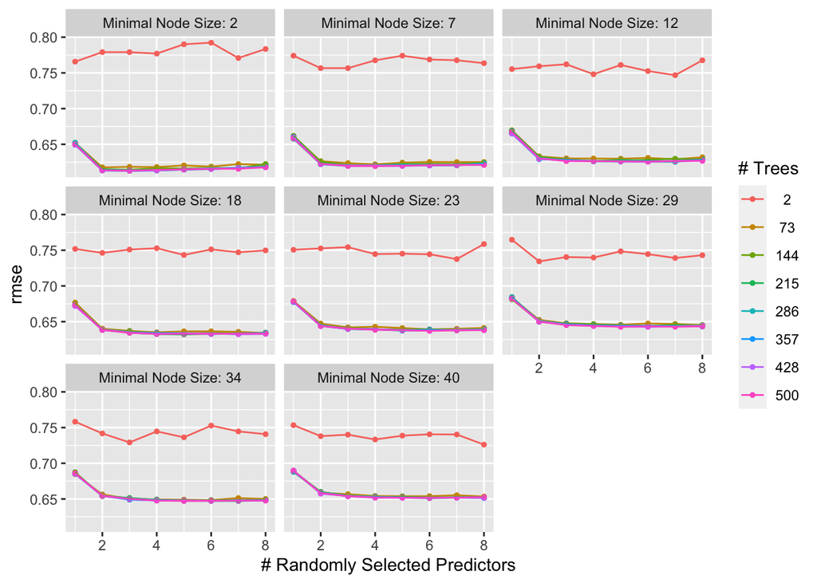

```r
autoplot(reg_rf_tune_res)
```

```r
best_complexity <- select_best(reg_rf_tune_res, metric = "rmse")

reg_rf_final <- finalize_workflow(reg_rf_wf, best_complexity)

reg_rf_final_fit <- fit(reg_rf_final, data = wine_train)
```

```r
augment(reg_rf_final_fit, new_data = wine_test) %>%
  rmse(truth = quality, estimate = .pred)
```

```
## # A tibble: 1 × 3
##   .metric .estimator .estimate
##   <chr>   <chr>          <dbl>
## 1 rmse    standard       0.593
```

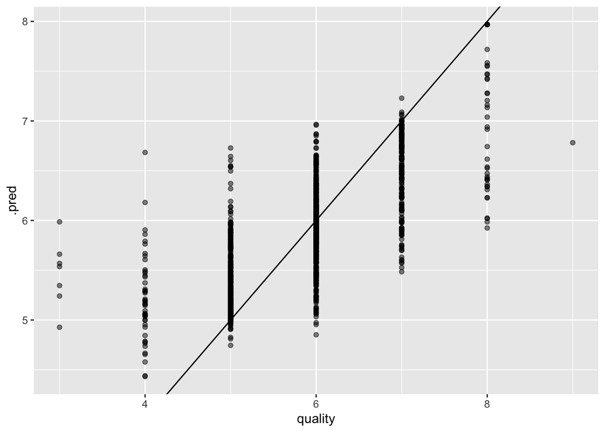

```r
augment(reg_rf_final_fit, new_data = wine_test) %>%
  ggplot(aes(quality, .pred)) +
  geom_abline() +
  geom_point(alpha = 0.5)
```

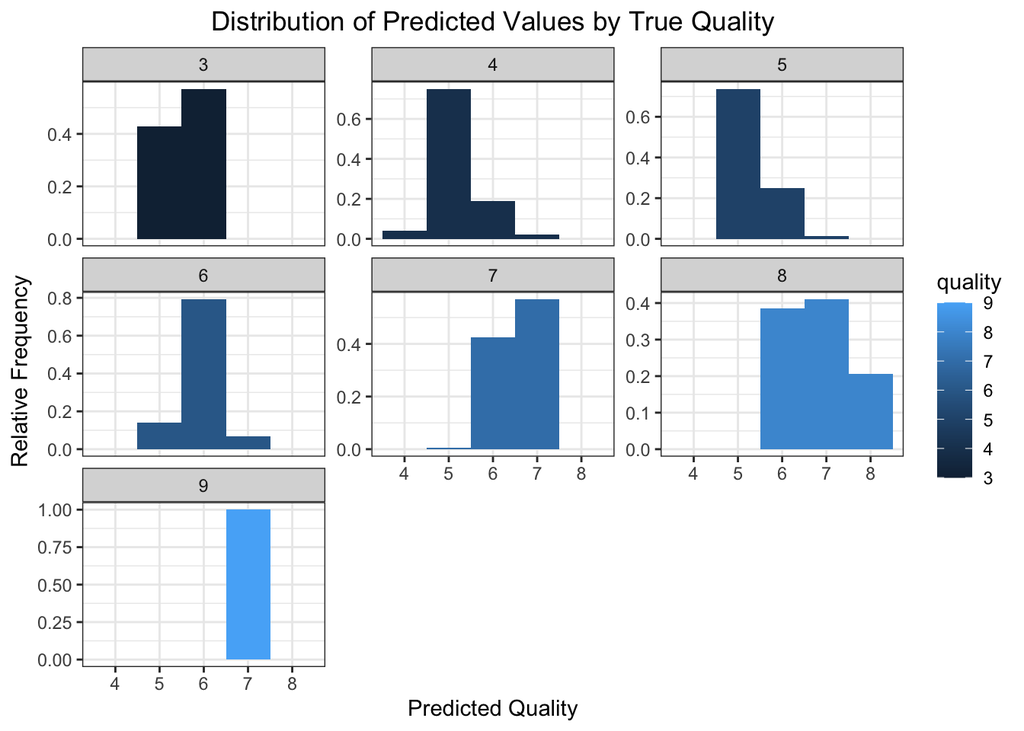

```r
augment(reg_rf_final_fit, new_data = wine_test) %>%
  ggplot(aes(x = .pred, fill=quality)) +
  geom_histogram(aes(y = stat(density)),binwidth = 1, )+
  facet_wrap(~quality, nrow = 3, scales = "free_y")+
  ggtitle("Distribution of Predicted Values by True Quality") +
  labs(x="Predicted Quality", y=" Relative Frequency") +
  scale_x_continuous(breaks = seq(3,9,1),minor_breaks = NULL)+
  theme_bw()+
  theme(plot.title = element_text(hjust = 0.5))
```

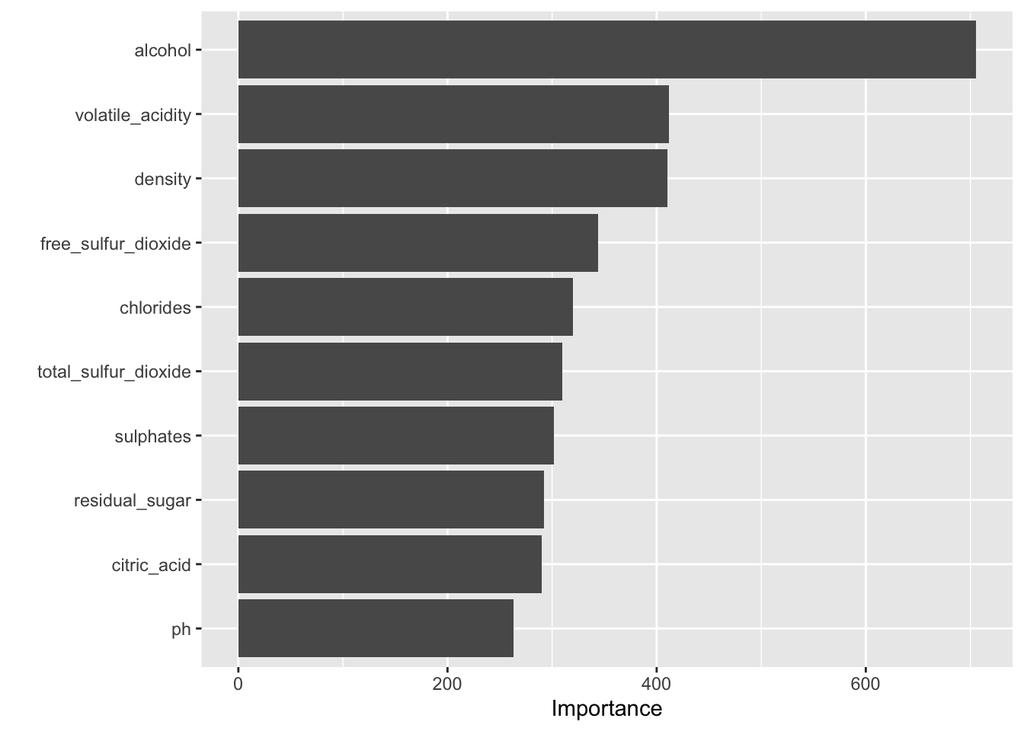

```r
reg_rf_final_fit%>%
  extract_fit_parsnip()%>%
  vip()
```

### Regression Model 3 - Boosted Tree

```r
reg_boost_spec <- boost_tree(trees = tune(), tree_depth = tune()) %>%
  set_engine("xgboost") %>%
  set_mode("regression")

reg_boost_wf <- workflow() %>%
  add_model(reg_boost_spec)%>%
  add_recipe(wine_recipe)

param_grid <- grid_regular(trees(range = c(2,1000)),
                           tree_depth(range = c(2,40)),
                           levels = 10)
```

```r
reg_boost_tune_res <- tune_grid(
  reg_boost_wf,
  resamples = wine_fold,
  grid = param_grid,
  metrics = metric_set(rmse)
)
```

[figure not shown]

```r
autoplot(reg_boost_tune_res)
```

```r
best_complexity <- select_best(reg_boost_tune_res, metric = "rmse")

reg_boost_final <- finalize_workflow(reg_boost_wf, best_complexity)

reg_boost_final_fit <- fit(reg_boost_final, data = wine_train)
```

```r
augment(reg_boost_final_fit, new_data = wine_test) %>%
  rmse(truth = quality, estimate = .pred)
```

```
## # A tibble: 1 × 3
##   .metric .estimator .estimate
##   <chr>   <chr>          <dbl>
## 1 rmse    standard       0.618
```

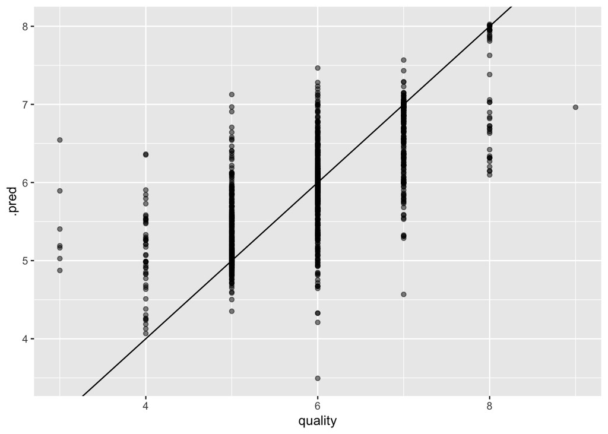

```r
augment(reg_boost_final_fit, new_data = wine_test) %>%
  ggplot(aes(quality, .pred)) +
  geom_abline() +
  geom_point(alpha = 0.5)
```

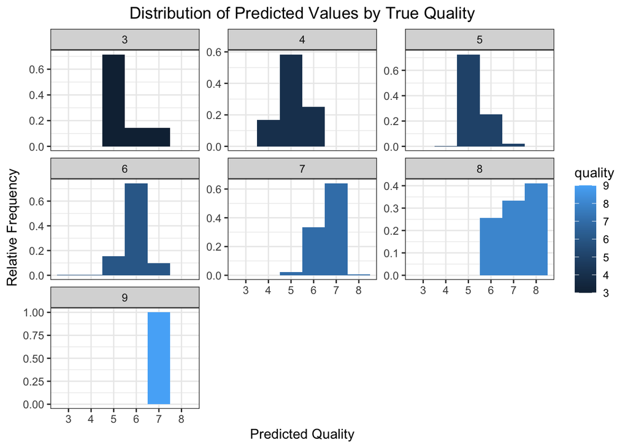

```r
augment(reg_boost_final_fit, new_data = wine_test) %>%
  ggplot(aes(x = .pred, fill=quality)) +
  geom_histogram(aes(y = stat(density)),binwidth = 1, )+
  facet_wrap(~quality, nrow = 3, scales = "free_y")+
  ggtitle("Distribution of Predicted Values by True Quality") +
  labs(x="Predicted Quality", y=" Relative Frequency") +
  scale_x_continuous(breaks = seq(3,9,1),minor_breaks = NULL)+
  theme_bw()+
  theme(plot.title = element_text(hjust = 0.5))
```

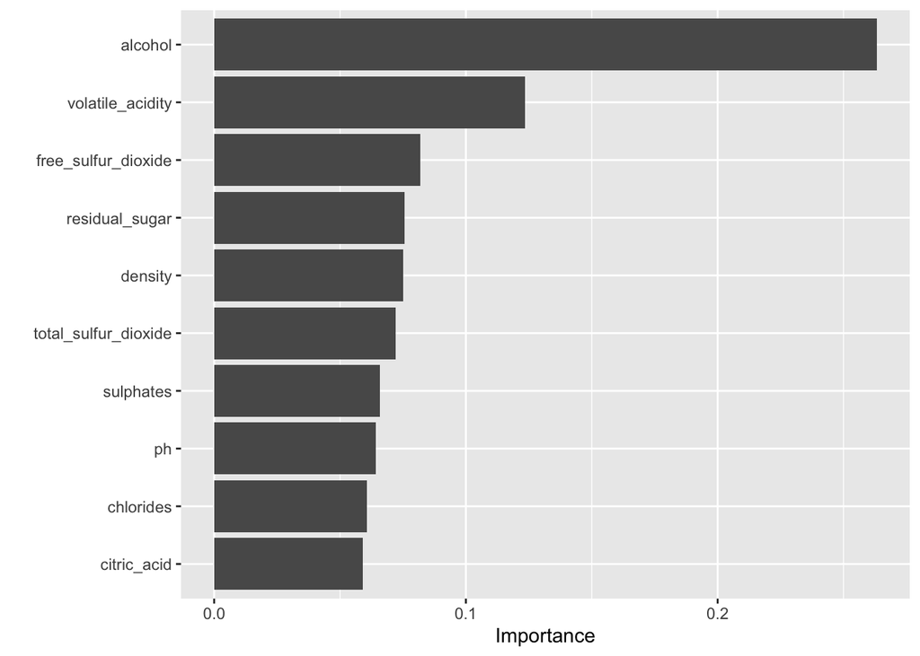

```r
reg_boost_final_fit%>%
  extract_fit_parsnip()%>%
  vip()
```

### Regression Model 4 - KNN

```r
reg_knn_spec <- nearest_neighbor(neighbors = tune()) %>%
  set_engine("kknn") %>%
  set_mode("regression")

reg_knn_wf <- workflow() %>%
  add_model(reg_knn_spec)%>%
  add_recipe(wine_recipe)

param_grid <- grid_regular(neighbors(range = c(1,20)),
                           levels = 20)
```

```r
reg_knn_tune_res <- tune_grid(
  reg_knn_wf,
  resamples = wine_fold,
  grid = param_grid
)
```

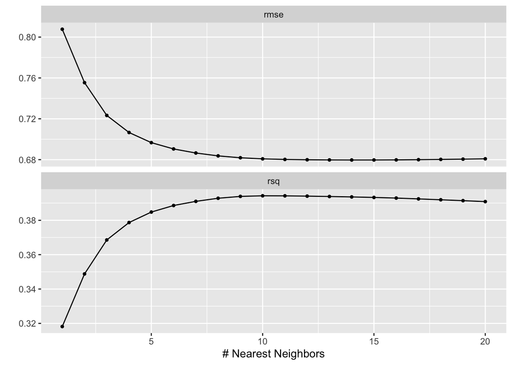

```r
autoplot(reg_knn_tune_res)
```

```r
best_complexity <- select_best(reg_knn_tune_res, metric = "rmse")

reg_knn_final <- finalize_workflow(reg_knn_wf, best_complexity)

reg_knn_final_fit <- fit(reg_knn_final, data = wine_train)
```

```r
augment(reg_knn_final_fit, new_data = wine_test) %>%
  rmse(truth = quality, estimate = .pred)
```

```
## # A tibble: 1 × 3
##   .metric .estimator .estimate
##   <chr>   <chr>          <dbl>
## 1 rmse    standard       0.668
```

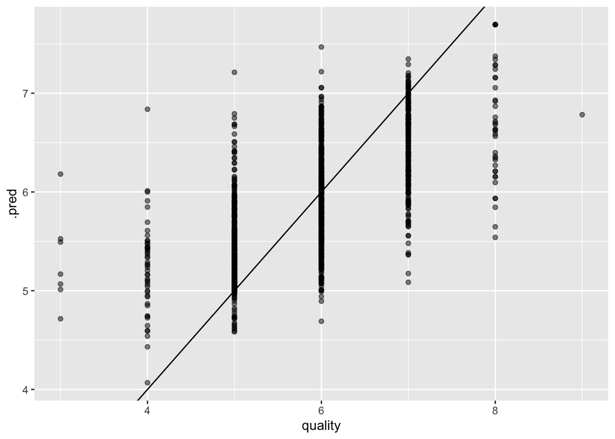

```r
augment(reg_knn_final_fit, new_data = wine_test) %>%
  ggplot(aes(quality, .pred)) +
  geom_abline() +
  geom_point(alpha = 0.5)
```

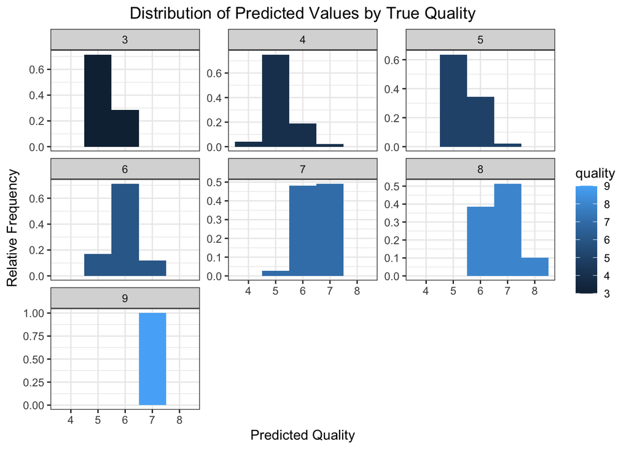

```r
augment(reg_knn_final_fit, new_data = wine_test) %>%
  ggplot(aes(x = .pred, fill=quality)) +
  geom_histogram(aes(y = stat(density)),binwidth = 1, )+
  facet_wrap(~quality, nrow = 3, scales = "free_y")+
  ggtitle("Distribution of Predicted Values by True Quality") +
  labs(x="Predicted Quality", y=" Relative Frequency") +
  scale_x_continuous(breaks = seq(3,9,1),minor_breaks = NULL)+
  theme_bw()+
  theme(plot.title = element_text(hjust = 0.5))
```